# Results shown on radar plots

The so-called radar plots are used to present the results. These plots are ideal for showing changes.

The Plot of fishing mortality (F) below shows the change in F for cod and mackerel. F for cod has been decreased while F on mackerel has increased. This can be seen as the red line (the present F) for cod is below or inside the the yellow line (the baseline for F). You cannot see the values of the baseline F or the present F, just the change, whch is calculated as the present value divided by the baseline value. For e.g. mackerel, the baseline F might have been 0.4 and the present F 0.5, corresponding to a change of 0.5/0.4 = 1.25.

The 100% line on the plot corresponds the maximum value or change on the plot, in this case the F change for mackerel.

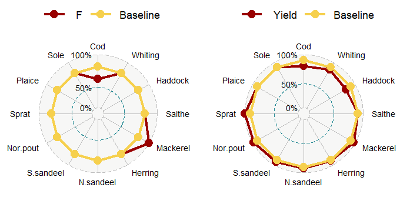

For the yield figure you can see that yield for cod is lower (or inside the baseline) than the baseline yield, as expected due to the decrease in F. For mackerel the present yield becomes higher than baseline yield, such that the red line is outside the yellow baseline. There are also changes for other stocks. This is because the predation mortalities for these changes as the the stock sizes of cod and mackerel changes. Plaice and sole are not eaten in the model and their stock size are therefore unchanged, as F on these species are not changed.